# RA

# 11 Exploratory data analysis

## 11.1 Introduction

- Questions around the data/Search for answers by visualizing, transforming, and modelling your data/Use what you learn to refine your questions and/or generate new questions.

## 11.2 Questions

- Using visualization and grouping. How are the observations within each subgroup similar to each other? How are the observations in separate clusters different from each other? How can you explain or describe the clusters? Why might the appearance of clusters be misleading?
- coord_cartesian() can be used to select unusual values

## 11.3.3 Exercises

1.Explore the distribution of each of the x, y, and z variables in diamonds. What do you learn? Think about a diamond and how you might decide which dimension is the length, width, and depth.

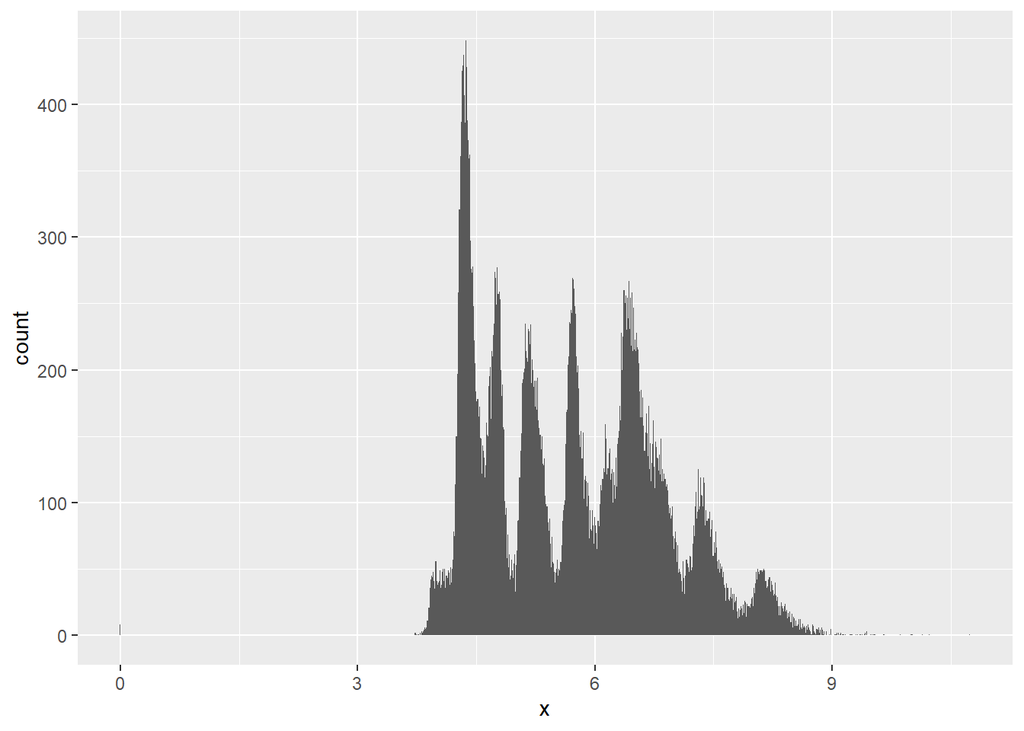

```r
#Distribution of x
ggplot(diamonds) +
  geom_histogram(mapping = aes(x = x), binwidth = 0.01)
```

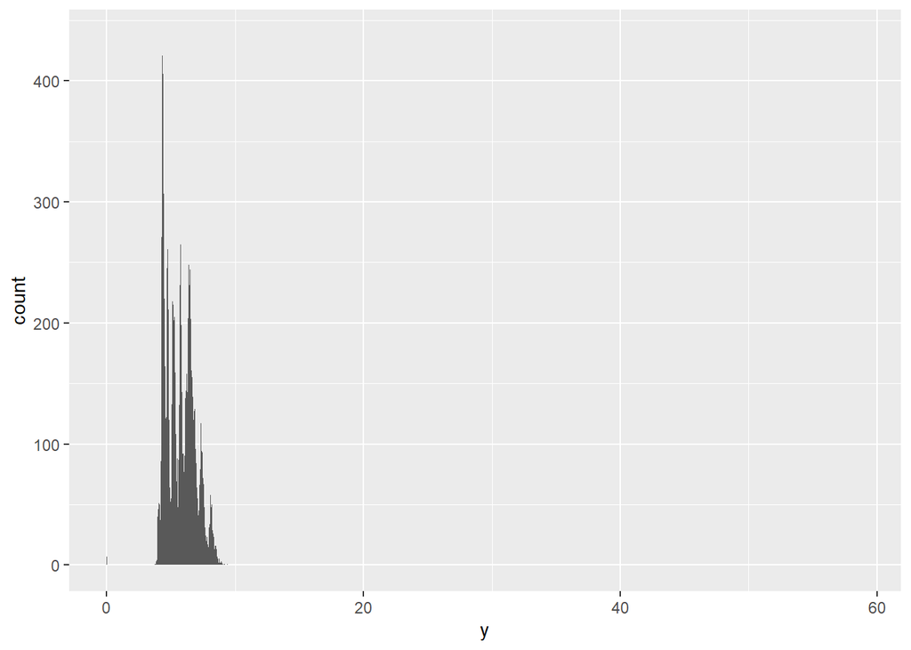

```r
#Distribution of y
ggplot(diamonds) +
  geom_histogram(mapping = aes(x = y), binwidth = 0.01)
```

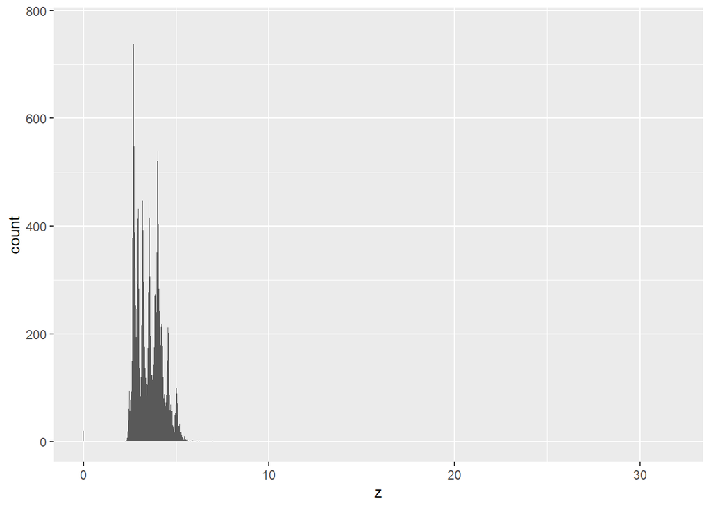

```r
#Distribution of z
ggplot(diamonds) +
  geom_histogram(mapping = aes(x = z), binwidth = 0.01)
```

2.Explore the distribution of price. Do you discover anything unusual or surprising? (Hint: Carefully think about the binwidth and make sure you try a wide range of values.)

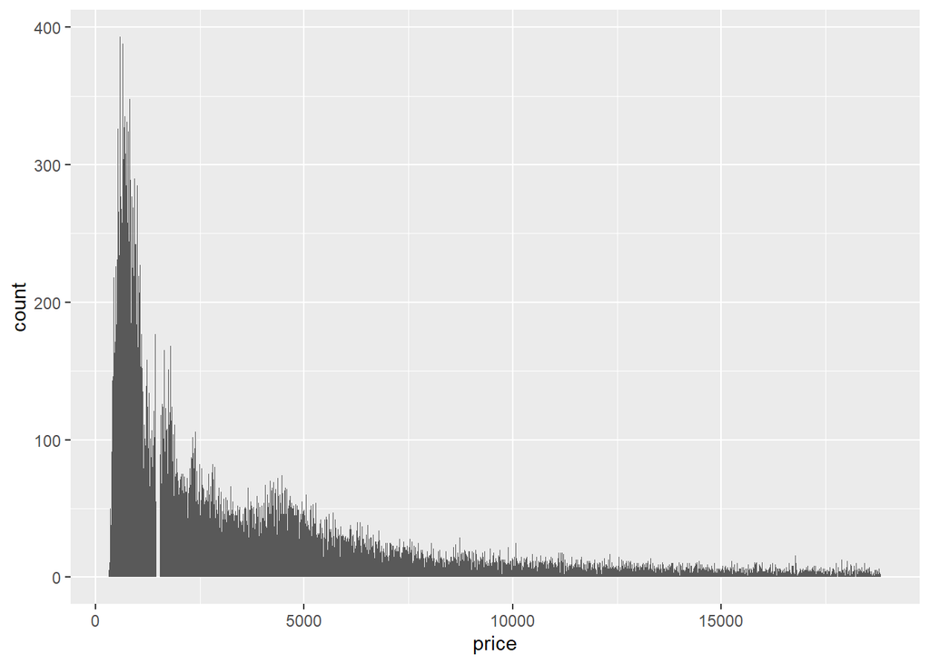

```r
ggplot(diamonds, aes(x = price)) +
  geom_histogram(binwidth = 10, center = 0)
```

3.How many diamonds are 0.99 carat? How many are 1 carat? What do you think is the cause of the difference?

```r
#Diamonds with 0.99 and 1 carat
diamonds %>%
  filter(carat >= 0.99, carat <= 1) %>%
  count(carat)
```

```
## # A tibble: 2 × 2
##   carat     n
##   <dbl> <int>
## 1  0.99    23
## 2  1     1558
```

- There are 1558 1-carat diamonds and 23 0.99-carat diamonds. The difference could be natural pheromone that 0.99-carat diamonds are naturally more rare.

4.Compare and contrast coord_cartesian() vs. xlim() or ylim() when zooming in on a histogram. What happens if you leave binwidth unset? What happens if you try and zoom so only half a bar shows?

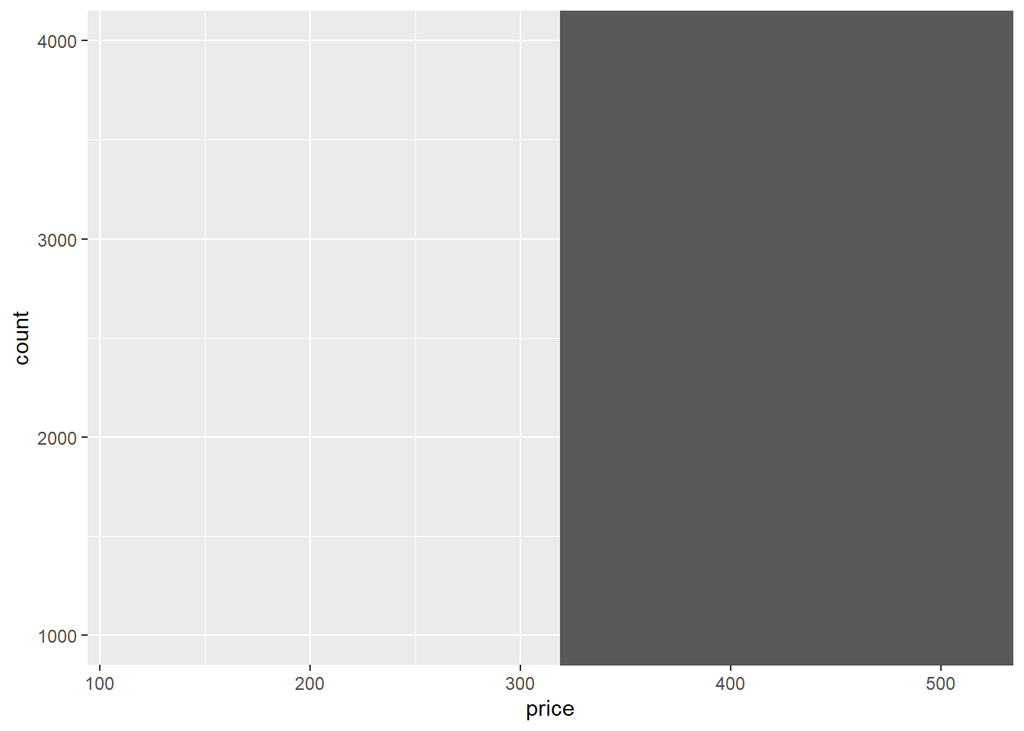

```r
#Leave bin width unset
ggplot(diamonds) +
  geom_histogram(mapping = aes(x = price)) +
  coord_cartesian(xlim = c(114, 514), ylim = c(1000, 4000))
```

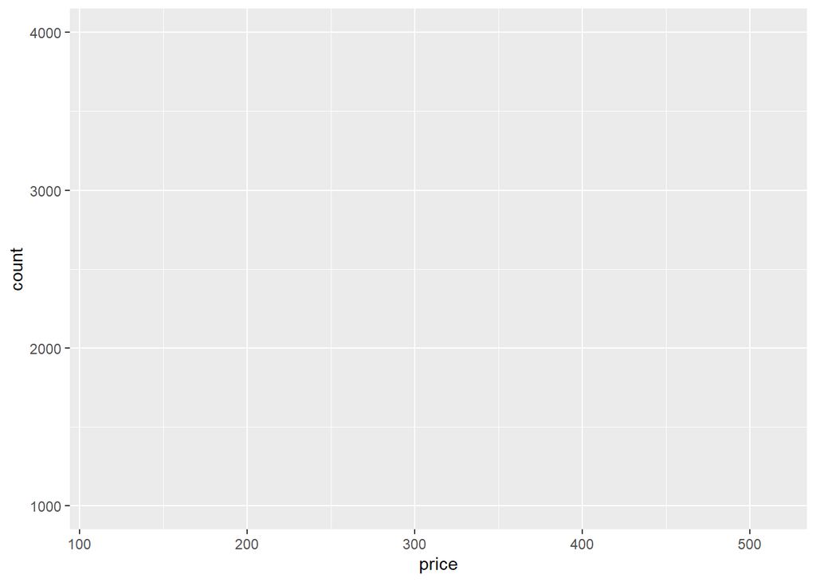

```r
ggplot(diamonds) +
  geom_histogram(mapping = aes(x = price)) +
  xlim(114, 514) +
  ylim(1000, 4000)
```

## 11.4 Unusual Vlaves & Exercises

- Drop rows with strange values.

1.What happens to missing values in a histogram? What happens to missing values in a bar chart? Why is there a difference in how missing values are handled in histograms and bar charts?

- (Google)The missing values in a histogram would be removed. “In the geom_bar() function, NA is treated as another category. The x aesthetic in geom_bar() requires a discrete (categorical) variable, and missing values act like another category. In a histogram, the x aesthetic variable needs to be numeric, and stat_bin() groups the observations by ranges into bins. Since the numeric value of the NA observations is unknown, they cannot be placed in a particular bin, and are dropped.”

2.What does na.rm = TRUE do in mean() and sum()?

- It reomves NA values before calculating mean and sum.

3.Recreate the frequency plot of scheduled_dep_time colored by whether the flight was cancelled or not. Also facet by the cancelled variable. Experiment with different values of the scales variable in the faceting function to mitigate the effect of more non-cancelled flights than cancelled flights.

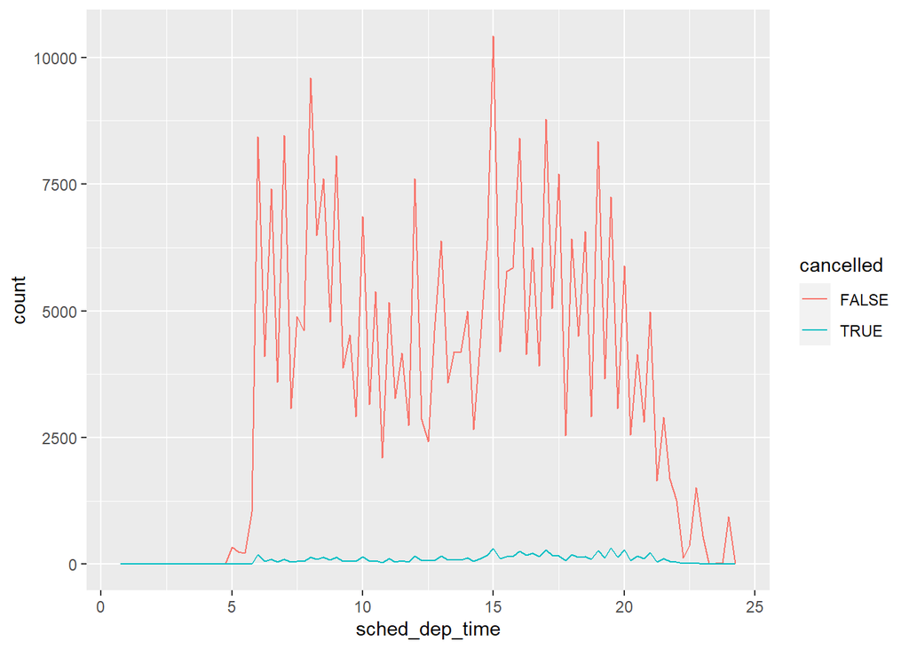

```r
nycflights13::flights |>
  mutate(
    cancelled = is.na(dep_time),
    sched_hour = sched_dep_time %/% 100,
    sched_min = sched_dep_time %% 100,
    sched_dep_time = sched_hour + (sched_min / 60)
  ) |>
  ggplot(aes(x = sched_dep_time)) +
  geom_freqpoly(aes(color = cancelled), binwidth = 1/4)
```

## 11.5

- Covariation is the tendency for the values of two or more variables to vary together in a related way.

### 11.5.1 A categorical and a numerical variable

- fct_reorder() to reorder variables for a more information disply.

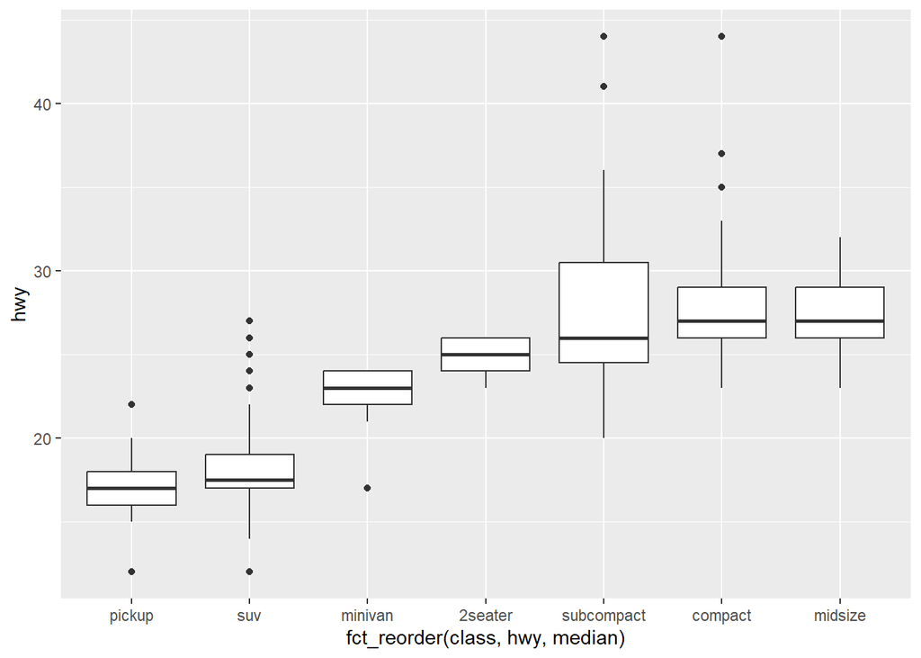

```r
ggplot(mpg, aes(x = fct_reorder(class, hwy, median), y = hwy)) +
  geom_boxplot()
```

### 11.5.1.1 Exercises

1.Use what you’ve learned to improve the visualization of the departure times of cancelled vs. non-cancelled flights.

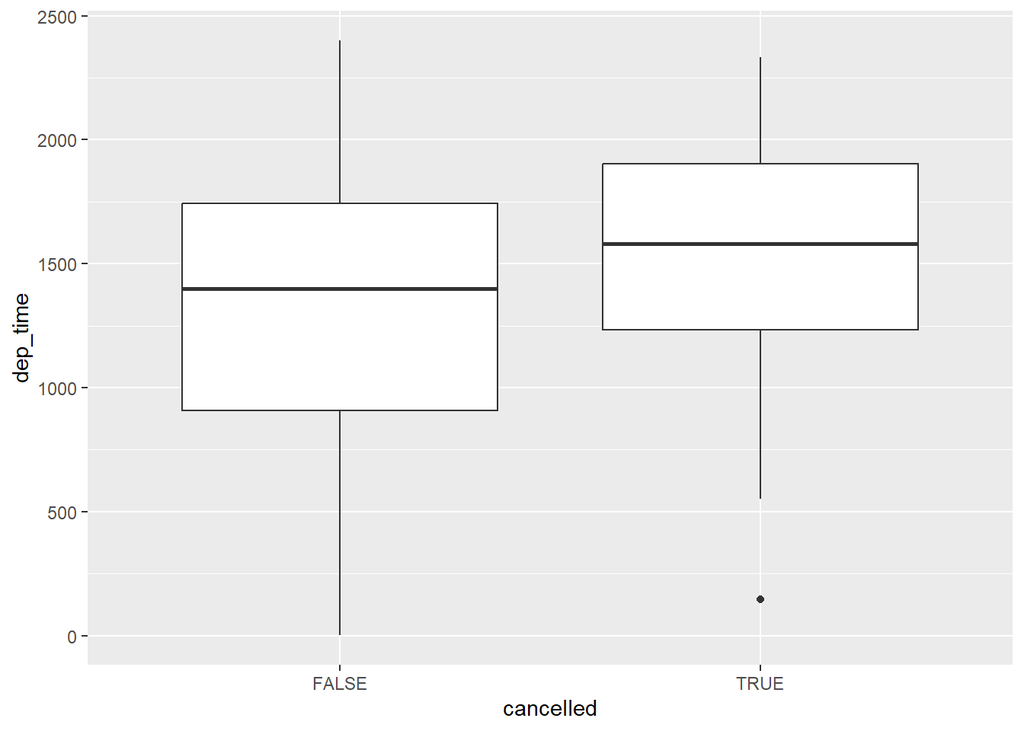

```r
nycflights13::flights |>
  mutate(cancelled = is.na(dep_time) | is.na(arr_time)) %>%
  ggplot() +
  geom_boxplot(aes(x = cancelled, y = dep_time))
```

2.Based on EDA, what variable in the diamonds dataset appears to be most important for predicting the price of a diamond? How is that variable correlated with cut? Why does the combination of those two relationships lead to lower quality diamonds being more expensive?

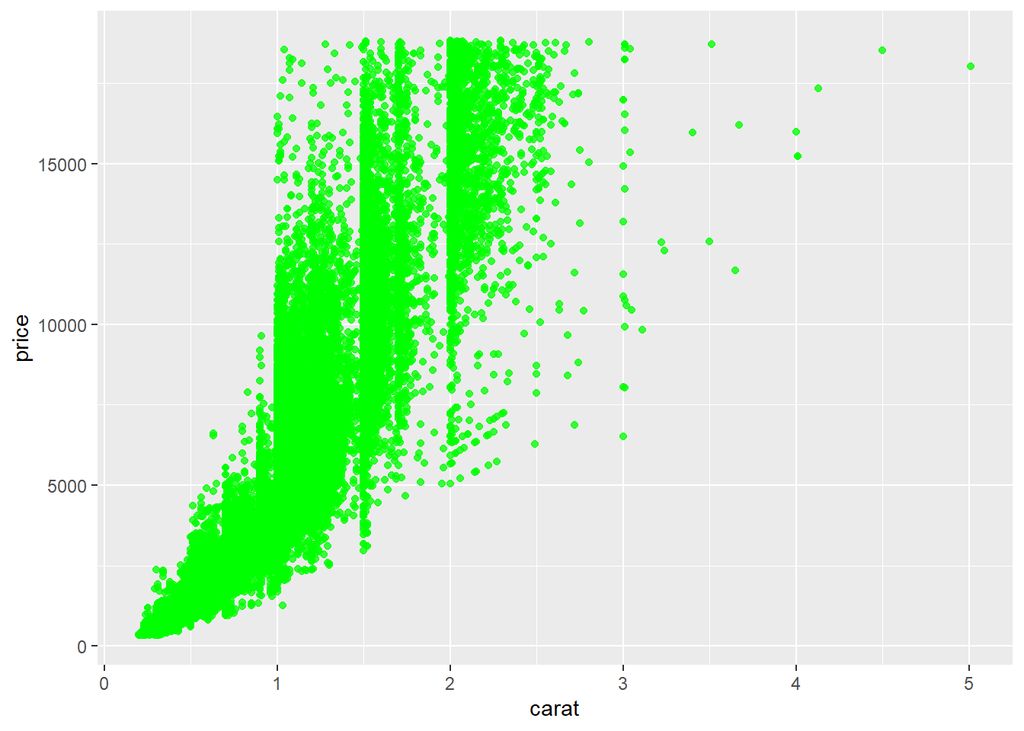

```r
#Correlation between carat and price
ggplot(diamonds) +
  geom_point(aes(x = carat, y = price), color = "green", alpha = 0.76)
```

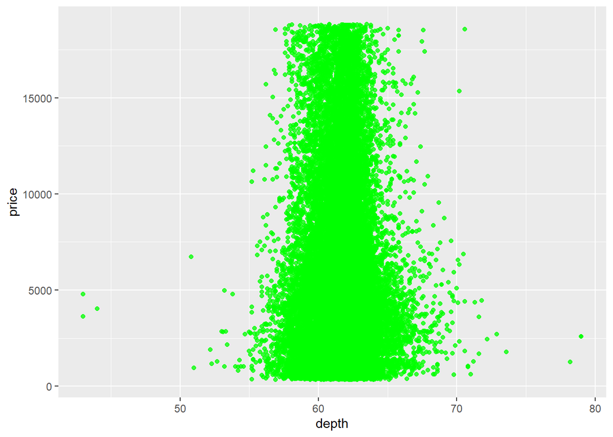

```r
#Correlation between depth and price
ggplot(diamonds) +
  geom_point(aes(x = depth, y = price), color = "green", alpha = 0.76)
```

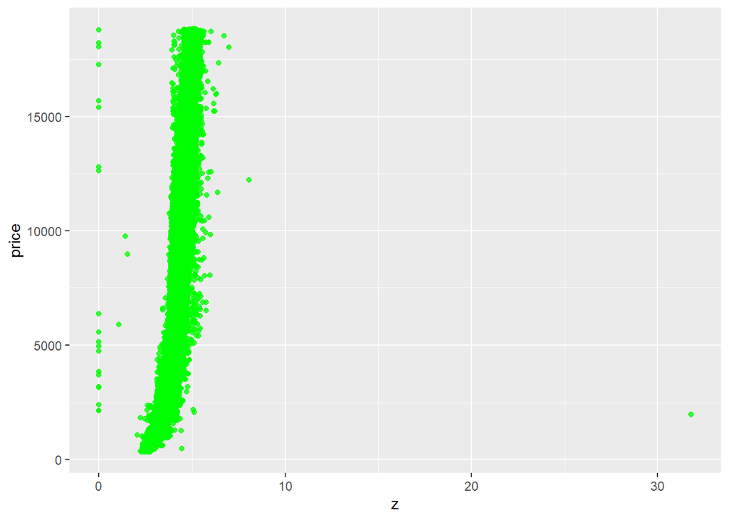

```r
#Correlation between z and price
ggplot(diamonds) +
  geom_point(aes(x = z, y = price), color = "green", alpha = 0.76)
```

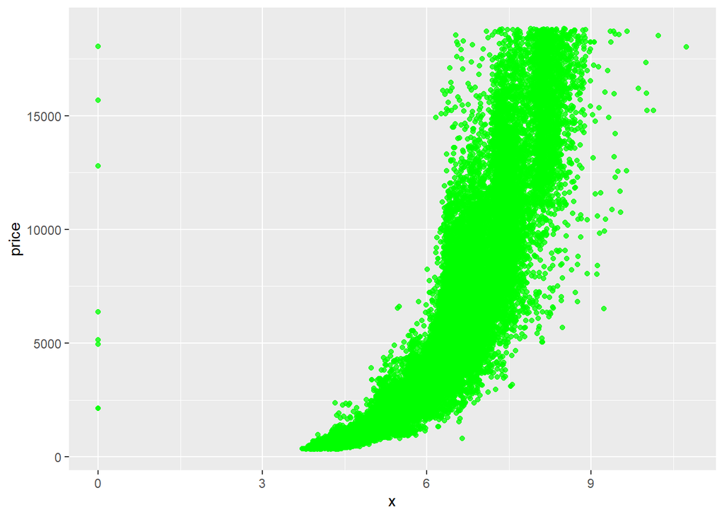

```r
#Correlation between x and price
ggplot(diamonds) +
  geom_point(aes(x = x, y = price), color = "green", alpha = 0.76)
```

3.Instead of exchanging the x and y variables, add coord_flip() as a new layer to the vertical boxplot to create a horizontal one. How does this compare to exchanging the variables?

4.One problem with boxplots is that they were developed in an era of much smaller datasets and tend to display a prohibitively large number of “outlying values”. One approach to remedy this problem is the letter value plot. Install the lvplot package, and try using geom_lv() to display the distribution of price vs. cut. What do you learn? How do you interpret the plots?

5.Create a visualization of diamond prices vs. a categorical variable from the diamonds dataset using geom_violin(), then a faceted geom_histogram(), then a colored geom_freqpoly(), and then a colored geom_density(). Compare and contrast the four plots. What are the pros and cons of each method of visualizing the distribution of a numerical variable based on the levels of a categorical variable?

6.If you have a small dataset, it’s sometimes useful to use geom_jitter() to avoid overplotting to more easily see the relationship between a continuous and categorical variable. The ggbeeswarm package provides a number of methods similar to geom_jitter(). List them and briefly describe what each one does.

### 11.5.2 Two categorical variables

- To create the plot with two categorical variables, use geom_count()
- Use dplyr to computing the counts between these variables.
- Visualize with geom_tile() and the fill aesthetic.

### 11.5.3 Two numerical variables

- Surely use geom_point() to plot the numerical variables.alpha aesthetic can add transparency.
- New tools to bin in one dimension: geom_bin2d() and geom_hex().

### 11.6 Patterns and models

- For a systematic relationship exists between two variables, it will appear as a pattern in the data. Such pattern should be considered: if it is a coincidence? What relationship implied by the pattern? How strong the relationship is? What other verbs may affect the relationship? Does the relationship change if you look at individual subgroups of the data?